# 9.6.2

Team 22

3/23/2020

Just as in the lab 9.6.1, we must load the Library “e1071”, as this library contains the svm funtion we want to use

```r
library(e1071)
```

We set the seed so we can replicate our findings, then we create an x and y matrix, and then combine them to create a data frame. The data in our data frame in generated with non-linear class boundary.

```r
set.seed(1)
x=matrix(rnorm (200*2) , ncol=2)
x[1:100,]=x[1:100,]+2
x[101:150 ,]=x[101:150,]-2
y=c(rep(1,150) ,rep(2,50))
dat=data.frame(x=x,y=as.factor(y))
```

We plot the to ensure that the class boundary is indeed non-linear

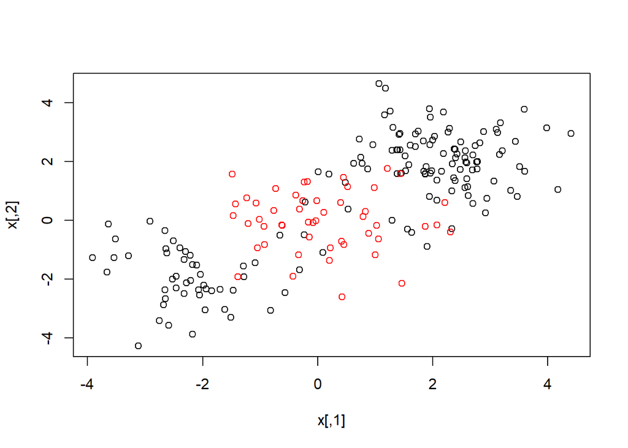

```r
plot(x, col=y)
```

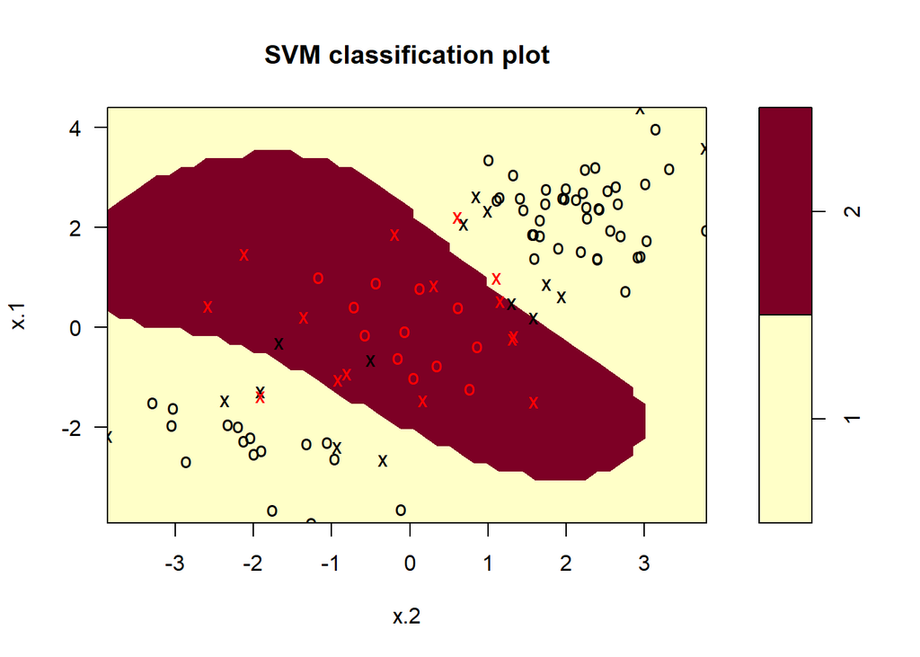

```r
train=sample (200,100)
svmfit=svm(y~., data=dat[train ,], kernel ="radial", gamma=1,cost=1)
plot(svmfit , dat[train ,])
```

The plot shows that the resulting SVM has a decidedly non-linear boundary. We use the summary() function to obtain more information about the SVM fit, such as Number of Support Vectors or Number of Classes.

```r
summary(svmfit)
```

```
##
## Call:
## svm(formula = y ~ ., data = dat[train, ], kernel = "radial",
##     gamma = 1, cost = 1)
##
##
## Parameters:
##    SVM-Type:  C-classification
##  SVM-Kernel:  radial
##        cost:  1
##
## Number of Support Vectors:  31
##
##  ( 16 15 )
##
##
## Number of Classes:  2
##
## Levels:
##  1 2
```

We see from the that there are is a decent number of training errors in this SVM fit. We can reduce these training errors by increasing the value of cost, however, this can cause a more irregular decision boundary and rissk of overfitting the data.

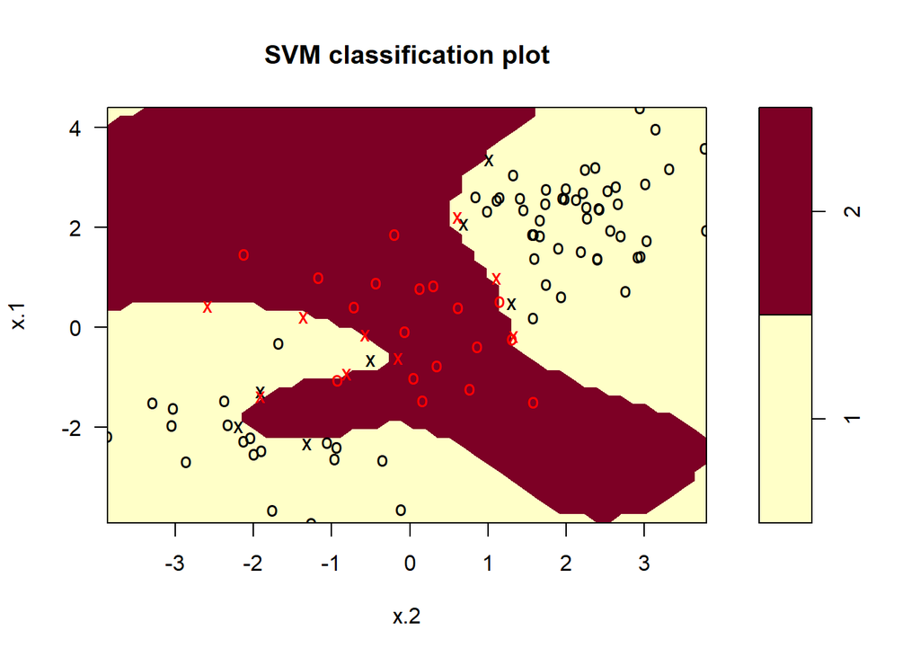

```r
svmfit=svm(y~., data=dat[train ,], kernel ="radial",gamma=1,cost=1e5)
plot(svmfit ,dat[train ,])
```

We can perform cross-validation using tune() to select the best choice of gamma and cost for an SVM with a “radial” kernel

```r
set.seed(1)
tune.out=tune(svm , y~., data=dat[train ,], kernel ="radial",ranges=list(cost=c(0.1,1,10,100,1000), gamma=c(0.5,1,2,3,4) ))
summary (tune.out)
```

```
##
## Parameter tuning of 'svm':
##
## - sampling method: 10-fold cross validation
##
## - best parameters:
##  cost gamma
##     1   0.5
##
## - best performance: 0.07
##
## - Detailed performance results:
##     cost gamma error dispersion
## 1  1e-01   0.5  0.26 0.15776213
## 2  1e+00   0.5  0.07 0.08232726
## 3  1e+01   0.5  0.07 0.08232726
## 4  1e+02   0.5  0.14 0.15055453
## 5  1e+03   0.5  0.11 0.07378648
## 6  1e-01   1.0  0.22 0.16193277
## 7  1e+00   1.0  0.07 0.08232726
## 8  1e+01   1.0  0.09 0.07378648
## 9  1e+02   1.0  0.12 0.12292726
## 10 1e+03   1.0  0.11 0.11005049
## 11 1e-01   2.0  0.27 0.15670212
## 12 1e+00   2.0  0.07 0.08232726
## 13 1e+01   2.0  0.11 0.07378648
## 14 1e+02   2.0  0.12 0.13165612
## 15 1e+03   2.0  0.16 0.13498971
## 16 1e-01   3.0  0.27 0.15670212
## 17 1e+00   3.0  0.07 0.08232726
## 18 1e+01   3.0  0.08 0.07888106
## 19 1e+02   3.0  0.13 0.14181365
## 20 1e+03   3.0  0.15 0.13540064
## 21 1e-01   4.0  0.27 0.15670212
## 22 1e+00   4.0  0.07 0.08232726
## 23 1e+01   4.0  0.09 0.07378648
## 24 1e+02   4.0  0.13 0.14181365
## 25 1e+03   4.0  0.15 0.13540064
```

```r
table(true=dat[-train ,"y"], pred=predict (tune.out$best.model ,newdata =dat[-train ,]))
```

```
##     pred
## true  1  2
##    1 67 10
##    2  2 21
```

In conclusion we see notice that 12/100 (12%) of the test observations are misclassified by this SVM.